# DataExplorer Package

Cynthia Petrossian, Sally Heo, Tadeo Zuniga, Heather Carstensen

4/9/2022

## Load libraries and data

First install the DataExplorer package:

install.packages(“DataExplorer”)

Then load the packages and read in the data. We’re using the chemicaldata_maunalua.csv data frame we used previously during Week 7.

```r
library(here)
library(DataExplorer)
library(tidyverse)
library(ggthemes)

chem <- read_csv(here("DataExplorer", "data", "chemicaldata_maunalua.csv"))
```

#### Introduction to Visualizing Data

Taking a first look at the data, we use two functions plot_str() & plot_intro() to visualize our data present and missing. This includes the data type, missing values and how the data types are distributed between the different columns.

**Arguments**

- **data:** input data
- **type:** type of network diagram. Defaults to diagonalNetwork.
- **max_level:** integer threshold of nested level to be visualized. Minimum 1 nested level and defaults to all.
- **print_network:** logical indicating if network graph should be plotted. Defaults to TRUE. … other arguments to be passed to plotting functions.

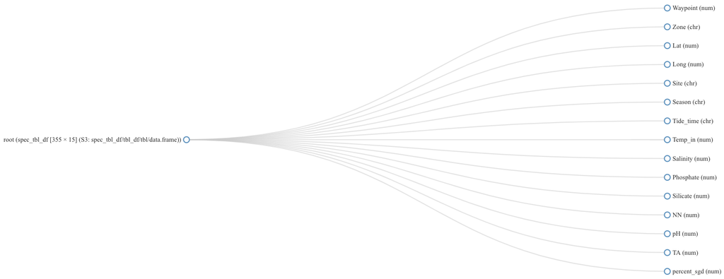

```r
plot_str(chem,
type = c("diagonal"),
max_level = NULL,
print_network = TRUE)

plot_str(chem,
type = c("radial"),
max_level = NULL,
print_network = TRUE)
```

[output not shown]

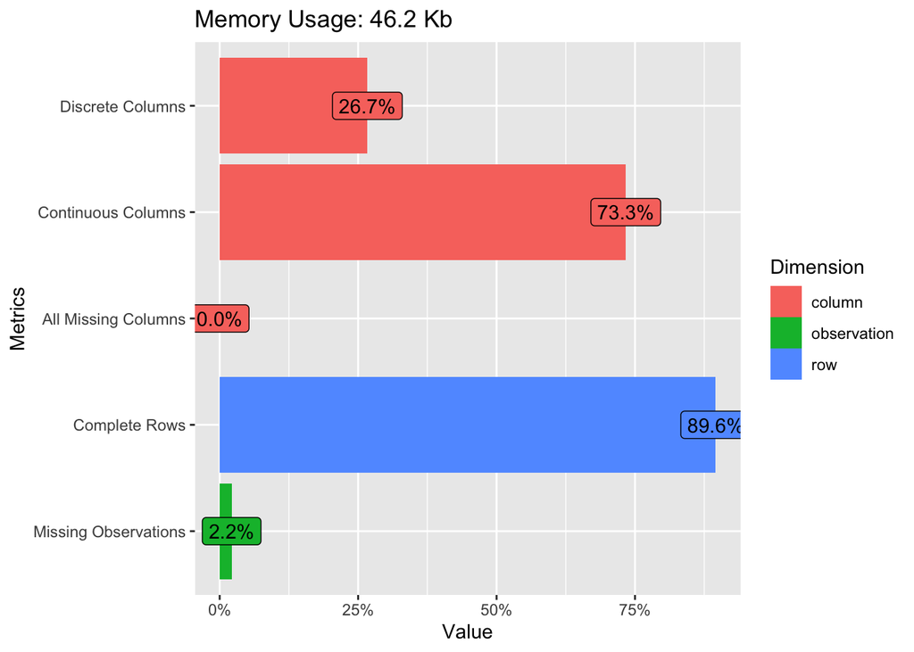

```r
plot_intro(chem)
```

## Making Plots

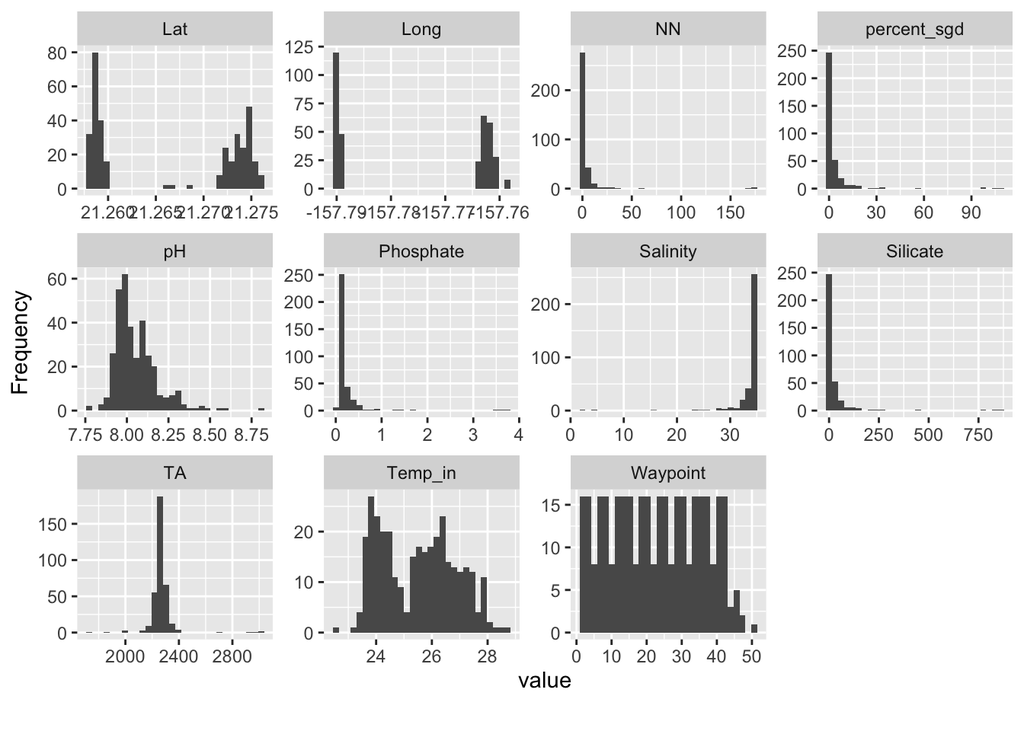

```r
plot_histogram(chem)
```

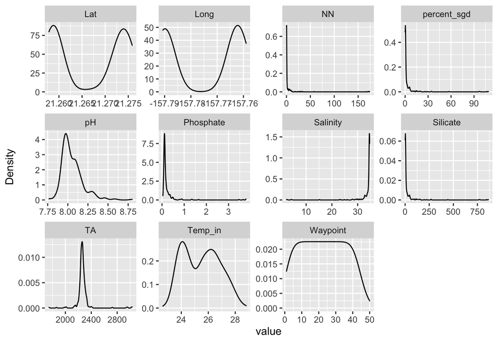

```r
plot_density(chem)
```